# Lab2

Jamil Ahmed

2024-01-30

# Task 1

```r
# This is the directory structure to my data

getwd()
```

```
## [1] "C:/Users/Ahmed/OneDrive/Desktop/Math Labs/Lab 2"
```

# Task 2

```r
#   Read the file and obtain the first six lines of the data using “head()”

dird="C:/Users/Ahmed/OneDrive/Desktop/Math Labs/Lab 2/DATAxls/"
#function to read data

myread=function(csv){
  fl=paste(dird,csv,sep="")
  read.table(fl,header=TRUE,sep=",")
}
mpg.df=myread("EPAGAS.csv")
head(mpg.df)
```

```
##    MPG
## 1 36.3
## 2 41.0
## 3 36.9
## 4 37.1
## 5 44.9
## 6 36.8
```

# Task 3

```r
# Make the object mpg, the number of miles per gallon vector.
mpg= mpg.df$MPG
head(mpg)
```

```
## [1] 36.3 41.0 36.9 37.1 44.9 36.8
```

```r
# Transform the mpg variable to z and verify these results.
z=(mpg-mean(mpg))/sd(mpg)
class(z)
```

```
## [1] "numeric"
```

```r
# Using z, find the values of mpg that are possible outliers.

z[abs(z)>=2 & abs(z)<=3]
```

```
## [1] -2.892596  2.111752 -2.148148
```

```r
# Using z, find the values of mpg that defined as outliers.
mpg[abs(z)>3]
```

```
## [1] 44.9
```

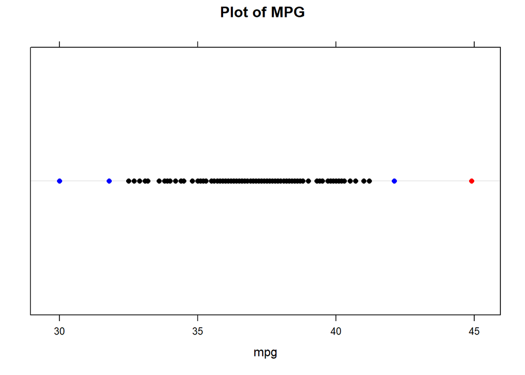

```r
# Plot the outliers in red and the possible outliers in blue
mycol = ifelse(abs(z)>3, "Red",
        ifelse(abs(z)>=2 &abs(z)<=3,"Blue", "Black"))

library(lattice)
dotplot(mpg,col=mycol, main="Plot of MPG")
```

# Task 4

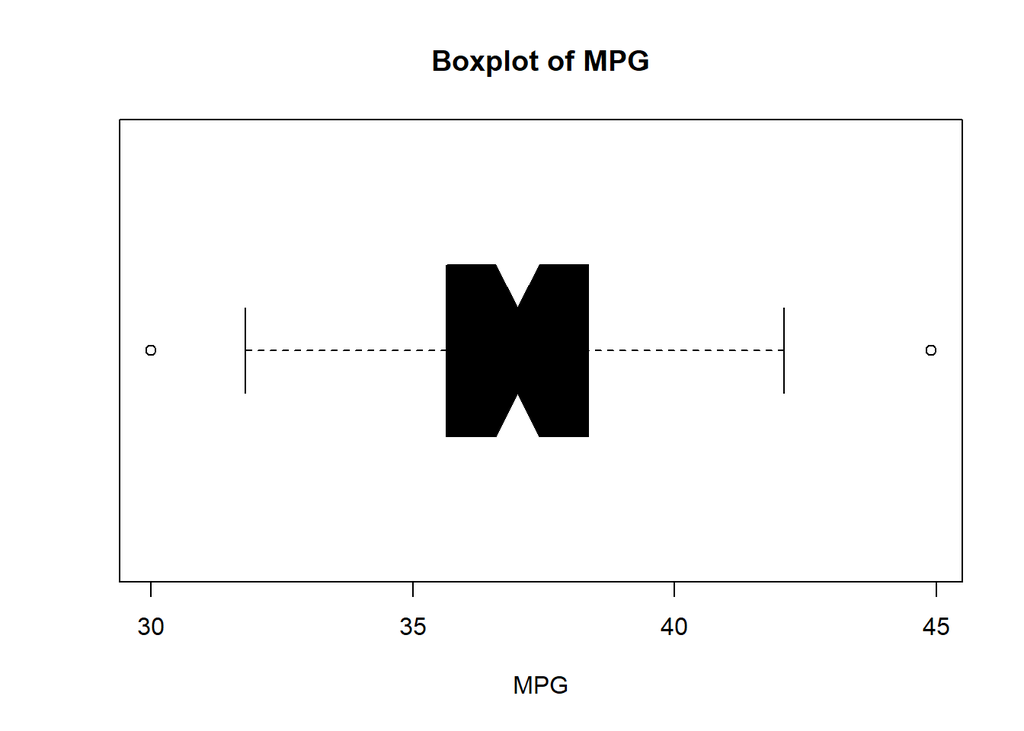

```r
#   Make a boxplot of the mpg variable
boxplot(mpg,main="Boxplot of MPG",xlab= "MPG",col="Black",horizontal=TRUE,notch=TRUE)
```

Predict the proportion of data within 2 standard deviations of the mean of the mpg data.

According to Chebyshev:

Within 2 standard deviations of the mean (k=2) At least 1-1/4=3/4 3/4

```r
 # Use R to calculate the exact proportion within 2 standard deviation of the mean.
length(mpg[abs(z)<2])/length(mpg)
```

```
## [1] 0.96
```

Does Chebyshev agree with the data?

Now use the empirical rule, what proportion (according to the rule) of the data should be within 2 standard deviations of the mean?

According to the Empirical rule, 95% of the data should be within 2 standard devations

How well does it correspond? It corresponds pretty well, Using R, we saw that 96% of the data is within 2 standard deviations of the mean, Where the Empirical rule estimates that 95% of the data is within 2 standard deviations.

Is the Empirical rule valid in this case? Why? Yes it is valid. The Empirical rule is an approximation. With a large enough sample size we should get closer and closer to 95%. We got 96%, but that does not invalidate the Empirical rule.

Here is a Histogram visualizing the data - We can see that the majority of the data is within 2 standard deviations of the mean (depicted by the green lines) further validating the Empirical rule.

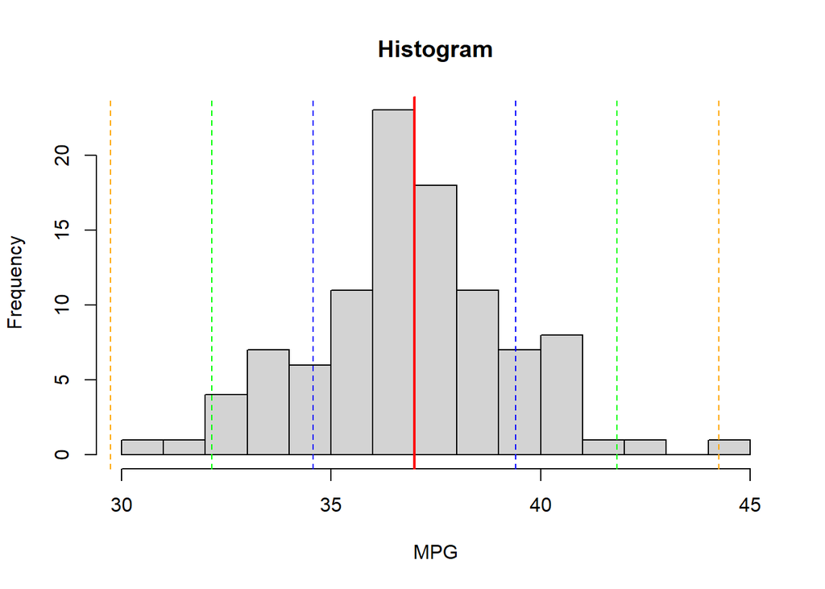

```r
hist(mpg, breaks = 20, main = "Histogram", xlab = "MPG", ylab = "Frequency")

# Add lines for mean and standard deviations
abline(v = mean(mpg), col = "red", lwd = 2)  # Mean
abline(v = mean(mpg) + c(-1, 1) * sd(mpg), col = "blue", lty = 2)  # ±1 SD
abline(v = mean(mpg) + c(-2, 2) * sd(mpg), col = "green", lty = 2)  # ±2 SD
abline(v = mean(mpg) + c(-3, 3) * sd(mpg), col = "orange", lty = 2)  # ±3 SD
```